# Wyjaśnialne uczenie maszynowe – praca domowa 6

## Katarzyna Koprowska

### Analiza danych pochodzących ze strony grupy ProPublica, dotyczących COMPAS-u, czyli algorytmu przewidującego prawdopodobieństwo recydywizmu skazanych osób, używanego w Stanach Zjednoczonych. Do danych opasowałam dwa modele: XGBoost oraz las losowy – oba miały na celu predykcję binarną tego, czy czy dana osoba dopuści się recydywizmu w ciągu dwóch lat.

```
RandomForestClassifier(bootstrap=True, ccp_alpha=0.0, class_weight=None,
                       criterion='gini', max_depth=3, max_features='auto',
                       max_leaf_nodes=None, max_samples=None,
                       min_impurity_decrease=0.0, min_impurity_split=None,
                       min_samples_leaf=1, min_samples_split=2,
                       min_weight_fraction_leaf=0.0, n_estimators=100,
                       n_jobs=None, oob_score=False, random_state=None,
                       verbose=0, warm_start=False)
```

```
XGBClassifier(base_score=0.5, booster='gbtree', colsample_bylevel=1,
              colsample_bynode=1, colsample_bytree=1, gamma=0,
              learning_rate=0.3, max_delta_step=0, max_depth=3,
              min_child_weight=3, missing=None, n_estimators=12, n_jobs=1,
              nthread=None, objective='binary:logistic', random_state=0,
              reg_alpha=1, reg_lambda=1, scale_pos_weight=1, seed=None,
              silent=None, subsample=0.8, verbosity=1)
```

### TODO:

1. For the selected data set, train at least one tree-based ensemble model (random forest, gbm, catboost or any other boosting)
2. For selected variables from the model (1) calculate Partial Dependence Profiles and Accumulated Local Dependence
3. Train a second model with a different structure (neural nets, linear, other boosting) and find a variable that has different behaviour between models
4. Comment on the results for points (2) and (3)

#### Wagi zmiennych w modelu XGBoost: po lewej pochodzące bezpośrednio z modelu, po prawej uzyskane za pomocą algorytmu permutacyjnego (opisanego w poprzedniej pracy domowej).

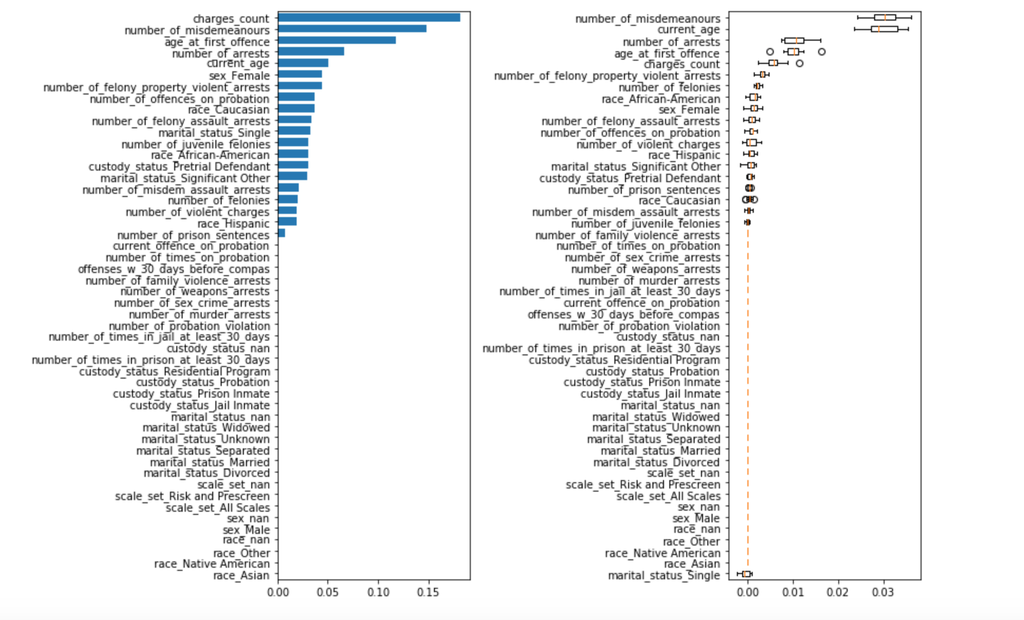

#### Analogiczne zestawienie dla modelu lasu losowego.

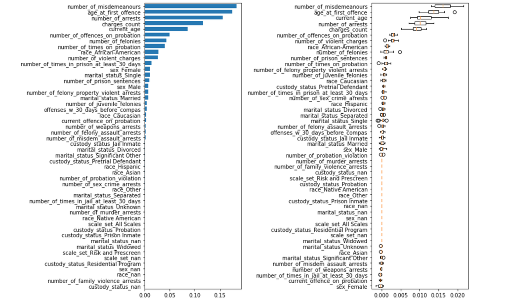

Najważniejszymi zmiennymi wg obu modeli są te dotyczące wieku (**current_age** oraz **age_at_first_offence**) oraz te dotyczące historii kryminalnej (**charges_count** (liczba oskarżeń) oraz **number_of_mideameanours** (liczba wykroczeń).

#### Partial Dependence Plot dla zmiennych dotyczących wieku.

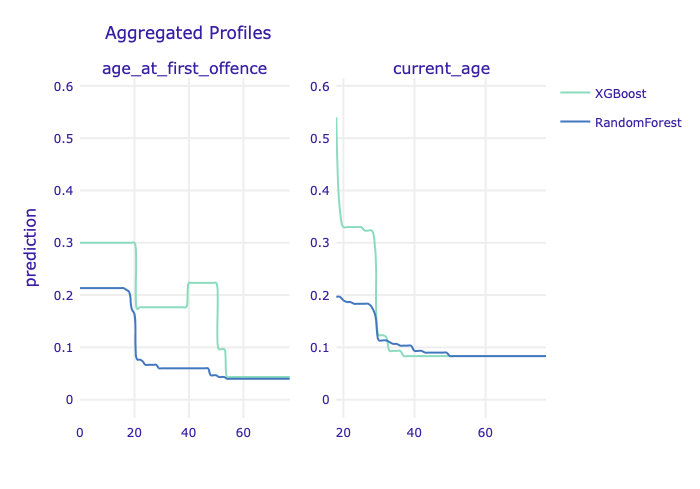

#### Accumulated Local Dependence dla zmiennych dotyczących wieku.

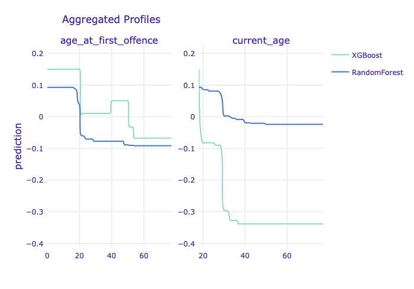

W przypadku obu profili widzimy, że zarówno obecny wiek, jak i wiek pierwszego wykroczenia zmniejszają predykcję: z reguły im młodsze są zatrzymane osoby i im wcześniej zeszły na kryminalną drogę, tym większe jest prawdopodobieństwo ich recydywy. W przypadku wieku pierwszego wykroczenia jest jednak wyraźny skok w okolicach 40 r.ż., po którym do ok. 50-tki mamy zwiększone prawdopodobieństwo recydywy w stosunku do tego tuż przed 40-stką -- być może chodzi o tzw. drugą młodość?

Model lasu losowego wykazuje znacznie większą stabilność w przypadku obu profili w porównaniu do modelu XGBoosta.

Oba profile nie różnią się od siebie znacząco.

#### Partial Dependence Plot dla zmiennych dotyczących historii kryminalnej.

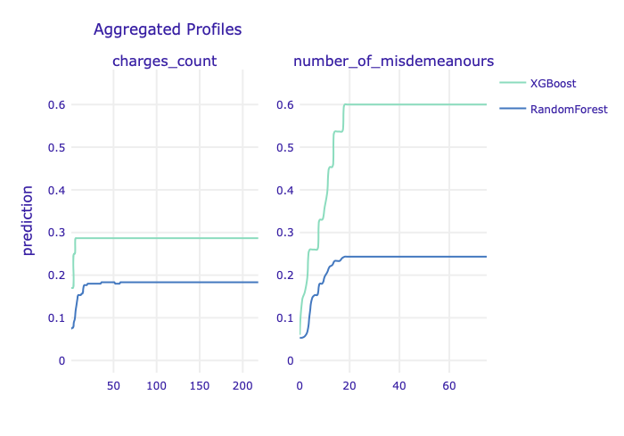

#### Accumulated Local Dependence dla zmiennych dotyczących historii kryminalnej.

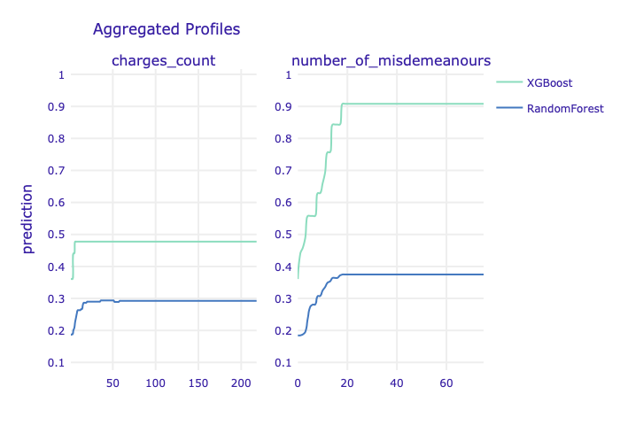

Tutaj bez niespodzianek: dość intuicyjnym jest, że im bogatsza jest historia kryminalna danej osoby, tym większe ma ona prawdopodobieństwo popełnienia kolejnego przestępstwa, stabilizuje się ono jednak już w okolicy kilku-kilkunastu oskarżeń (**charges_count**) oraz ok. 20 wykroczeń (**number_of_misdemeanours**).

Ponownie widzimy większą "zachowawczość" modelu lasu losowego.

Oba profile są znowu do siebie bardzo podobne.

### Interesujący jest również wpływ tzw. danych wrażliwych, a więc rasy oraz płci.

#### Poniżej zamieszczone zostały wykresy PDP dla rasy.

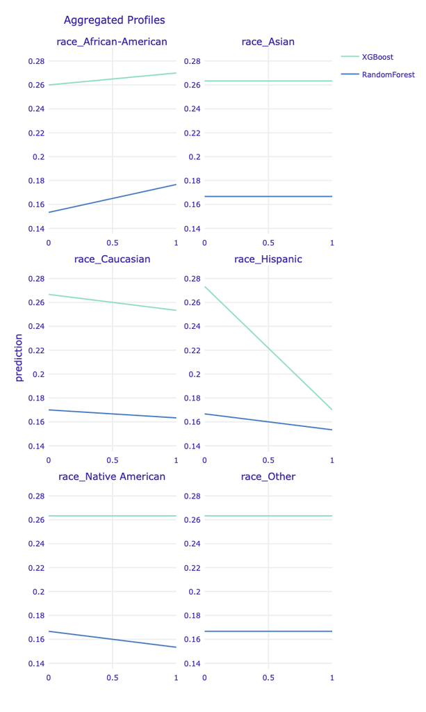

#### Wykresy ALE dla rasy.

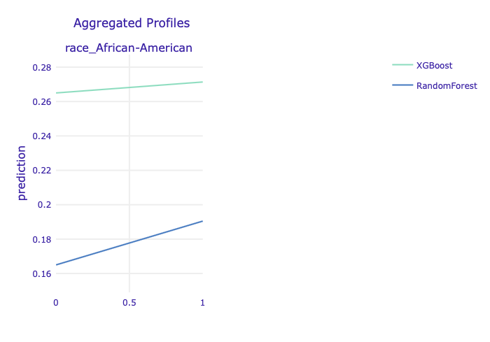

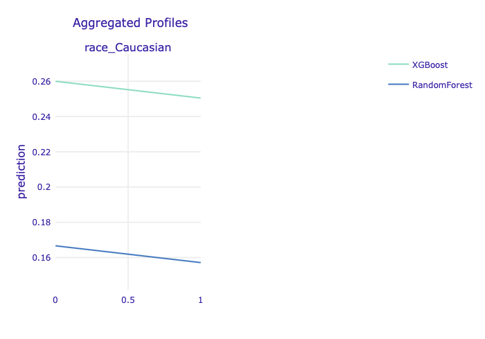

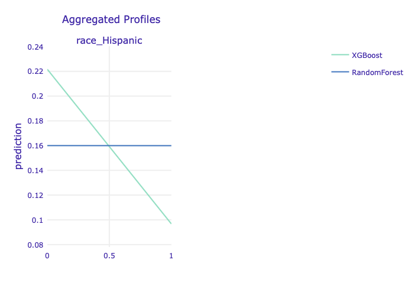

#### Wykresy PDP dla płci

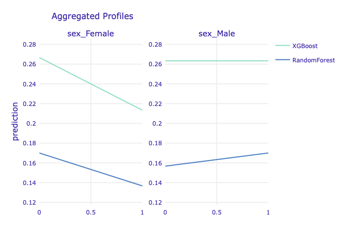

#### Wykresy ALE dla płci

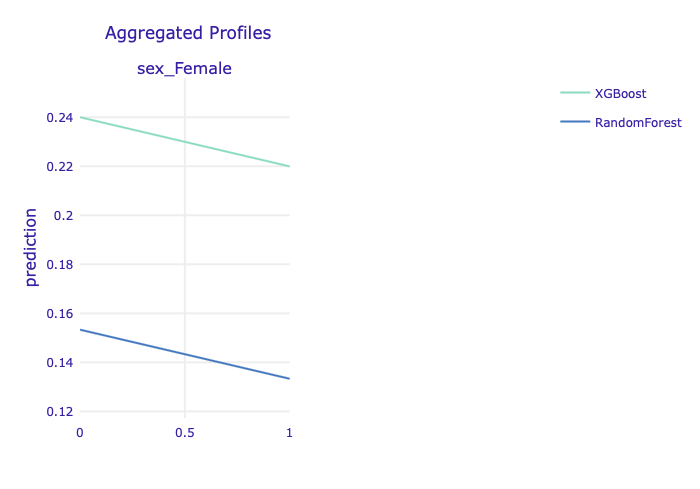

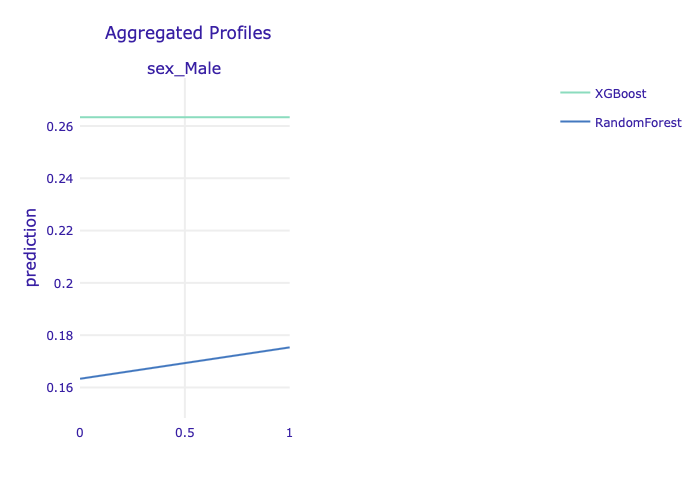

Profile dla płci pokazują odrobinę mniejsze prawdopodobieństwo recydywy dla kobiet w obu modelach.

Sytuacja mężczyzn jest nieco bardziej skomplikowana: w modelu lasu losowego bycie mężczyzną nieznacznie zwiększa predykcję, podczas gdy w XGBooście nie ma na nią wpływu. Należy jednak pamiętać, iż w przypadku obu modeli zmienna dotycząca płci męskiej nie miała zbyt dużej wagi.